# COTS Population Model: explore data

Sam Matthew, Camille Mellin, Damien Fordham, Kevin Shoemaker, …

April 6, 2016

```
## The current user is KEVIN
```

# COTS Population Model: objectives

# TODO LIST

- how to initialize the COTS population??? [KTS developed a crude method using reef-level densities…]
- determine how exactly the coral/cots interaction will work?
  - is there a maximal live coral cover for each grid cell? What determines this maximum
  - We have cover for two species of coral- how does this enter and influence the model?
  - Is the SDM just used to specify initial live coral cover? Or, does this SDM affect the model in a more long-lasting way?

# DATA DESCRIPTION

The population model uses data of three major types:

1. GIS Rasters: 0.01 degrees (ca. 1 km) resolution. Approx 1.3 million pixels. We chose to use a 1 km resolution to represent geographic variation within the Great Barrier Reef. We chose this resolution because it was the coarsest resolution that could successfully capture the vast majority of the small reefs in the landscape.
2. Population-level data: XYZ dataframe containing unique information (Z1, Z2, …) about each 1 km<sup>2</sup> reef segment, or “population” (ca. 17k populations).
3. Reef-level data: XYZ dataframe containing unique information (z1, Z2, …) about each reef (variable sizes) (ca. 2k reefs)

## Read in master population-level data

```
##   SAMPLE_ID      x      y REEF_ID mindistbarrier mindistcoast
## 1    X00001 143.08 -12.33     653           0.65         0.00
## 2    X00002 143.09 -12.36    1004           0.64         0.03
## 3    X00003 143.09 -12.35    1004           0.64         0.02
## 4    X00004 143.09 -12.25    4268           0.63         0.00
## 5    X00005 143.09 -12.23    4268           0.63         0.00
## 6    X00006 143.09 -12.16    3271           0.63         0.01
##   cars_no3_mean cars_no3_std cars_o2_mean cars_o2_std cars_po4_mean
## 1          0.31         0.31         4.17        0.28          0.18
## 2          0.32         0.33         4.16        0.31          0.18
## 3          0.32         0.33         4.16        0.30          0.18
## 4            NA           NA           NA          NA            NA
## 5            NA           NA           NA          NA            NA
## 6            NA           NA           NA          NA            NA
##   cars_po4_std cars_s_mean cars_s_std cars_si_mean cars_si_std cars_t_mean
```

[output cut: 34 more lines]

## Extract study region extent

```r
minx <- min(envData$x)-0.005  # farthest west
miny <- min(envData$y)-0.005  # farthest south
maxx <- max(envData$x)+0.005  # farthest east
maxy <- max(envData$y)+0.005  # farthest north
studyRegion <- extent(minx,maxx,miny,maxy)
cat(sprintf("Western margin is %s degrees, southern margin is %s degrees, eastern margin is %s degrees, and northern margin is %s degrees",minx,miny,maxx,maxy))
```

```
## Western margin is 143.075 degrees, southern margin is -24.995 degrees, eastern margin is 153.355 degrees, and northern margin is -12.005 degrees
```

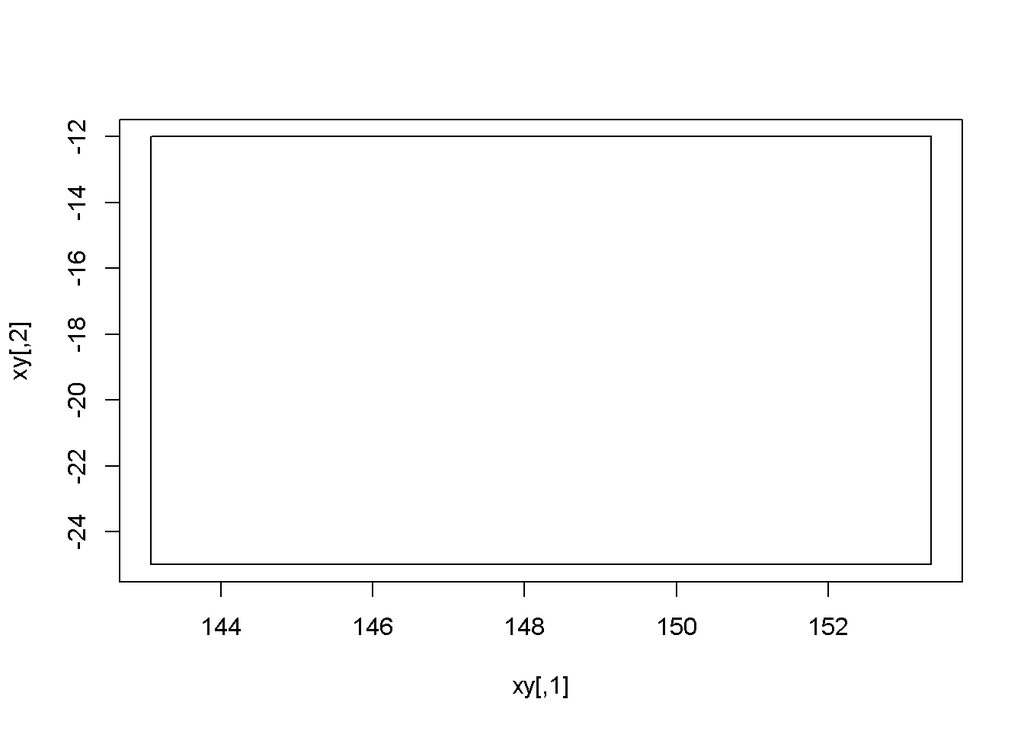

```r
plot(studyRegion)
```

## Make template raster

```r
template <- raster(ext=studyRegion,resolution=0.01,vals=0)   # empty raster
#plot(template)
setwd(SPATIALDATA_DIRECTORY)
writeRaster(template,filename="templateRaster.asc",format="ascii",overwrite=T)
```

```
## class       : RasterLayer
## dimensions  : 1299, 1028, 1335372  (nrow, ncol, ncell)
## resolution  : 0.01, 0.01  (x, y)
## extent      : 143.075, 153.355, -24.995, -12.005  (xmin, xmax, ymin, ymax)
## coord. ref. : NA
## data source : C:\Users\Kevin\Dropbox\CoTS_Model\Spatial Layers\templateRaster.asc
## names       : templateRaster
```

```r
totalCells <- length(template@data@values)    # 1,335,372 cells

cat(sprintf("total cells in study region raster is %s",totalCells))
```

```
## total cells in study region raster is 1335372
```

## Make reef ID raster

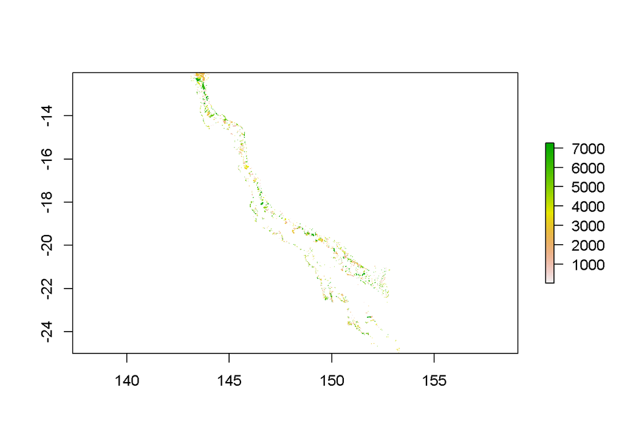

```r
   ## rasterize an environmental variable.
reefID <- as.numeric(envData$REEF_ID)
ndx <- !is.na(reefID)
reefIDraster <- rasterize(envData[,c('x','y')][ndx,], template, field=reefID[ndx])   # memory limitations

plot(reefIDraster)
```

# RMARKDOWN EXAMPLES- FOR REFERENCE

inline equation: $A = \pi*r^{2}$

Here is an example of embedded R code:

```r
a<-2+2
a
```

```
## [1] 4
```